# Analisis Filogenetico del Virus SARS-CoV-2

Roberto Castro Gómez A01425602 Dariana Vega Morales A01425755

### Hipótesis

Dado el tipo de flora y fauna que se encuentra en Oceanía, queremos determinar si las variantes de la región son distintas a las del resto del mundo. Se sospecha que podría existir una divergencia entre las variantes de Oceanía, la de Wuhan y alguna otra variante del hemisferio opuesto; en este caso, consideramos una variante de Kansas.

### Procesamiento de datos

Para definir los cambios de aminoácidos que podrían encontrarse, se genera una tabla que indica a qué tipo de aminoácido corresponde cada codón encontrado.

```r
library(seqinr)
library(dplyr)
library(ggplot2)


trad =    c(UUU="F", UUC="F", UUA="L", UUG="L",
            UCU="S", UCC="S", UCA="S", UCG="S",
            UAU="Y", UAC="Y", UAA="STOP", UAG="STOP",
            UGU="C", UGC="C", UGA="STOP", UGG="W",
            CUU="L", CUC="L", CUA="L", CUG="L",
            CCU="P", CCC="P", CCA="P", CCG="P",
            CAU="H", CAC="H", CAA="Q", CAG="Q",
            CGU="R", CGC="R", CGA="R", CGG="R",
            AUU="I", AUC="I", AUA="I", AUG="M",
            ACU="T", ACC="T", ACA="T", ACG="T",
            AAU="N", AAC="N", AAA="K", AAG="K",
            AGU="S", AGC="S", AGA="R", AGG="R",
            GUU="V", GUC="V", GUA="V", GUG="V",
            GCU="A", GCC="A", GCA="A", GCG="A",
            GAU="D", GAC="D", GAA="E", GAG="E",
            GGU="G", GGC="G", GGA="G", GGG="G")

ToARN = function(input) {
  newARN = as.vector(input)
  newARN[which(newARN=="t")] = "u"
  newARN = toupper(newARN)
  return (newARN)
}
```

Después, se crea la estructura de almacenamiento de los datos que se van analizando para mantener un control sobre las gráficas.

```r
df = data.frame(
  Mutation = character(),
  Codon = character(),
  Amino = character(),
  Position = integer(),
  Gene = character()
)
```

A continuación se procede a la lectura de las cadenas de ARN que serán comparadas. En este estudio, estamos comparando la estructura de la variante original de Wuhan con 5 variantes diferentes encontradas en la región de Oceanía. Las cadenas de ARN fueron obtenidas del sitio web del National Center for Biotechnology Information **(NCBI)**, donde se filtraron los datos específicamente para obtener información sobre el **SARS-CoV-2** donde posteriormente, se realizaron filtros adicionales para identificar las variantes encontradas en Oceanía.

```r
fRef = read.fasta("wuhan_sequence.txt")

fMexa = read.fasta("sequence_5.fasta")

mutaciones_reg = c()

nobs = 1
```

```r
for (i in seq(1,length(fRef),1)){
  anotaciones = attr(fRef[[i]], "Annot")
  atributos = unlist(strsplit(anotaciones,"\\[|\\]|:|=|\\.|\\("));
  geneName = atributos[which(atributos=="gene")+1]
  genRef = ToARN( fRef[[i]] )
  for (j in seq(i, length(fMexa),12)) {
    genMex = ToARN( fMexa[[i]] )
    if (length(genRef) == length(genMex)){
      dif = which(genRef != genMex)
      if (length(dif) > 0){
        for (x in dif){
          if (genRef[x] != "" && genMex[x] !="") {
            muta = paste(genRef[x],"to",genMex[x], sep="")
            inicioCodon = x - (x-1)%%3
            numCodon = as.integer((x-1)/3+1)
            codonOri = paste(genRef[inicioCodon], genRef[inicioCodon+1], genRef[inicioCodon+2],sep="")
            codonMex = paste(genMex[inicioCodon], genMex[inicioCodon+1], genMex[inicioCodon+2],sep="")
            codonChange = paste(codonOri,"to",codonMex, sep="")
            aminoChange = paste(trad[codonOri],numCodon,trad[codonMex], sep="")
            mutacion = paste(muta, codonChange, aminoChange, geneName, sep=" ")
            if (!mutacion %in% mutaciones_reg) {
              mutaciones_reg = c(mutaciones_reg, mutacion)
            }
          }
        }
      }
    }else{
      genRefLength = length(genRef)
      genMexLength = length(genMex)

      if (genRefLength < genMexLength) {
        genRef = c(genRef, rep("", genMexLength - genRefLength))
      } else {
        genMex = c(genMex, rep("", genRefLength - genMexLength))
      }
      dif = which(genRef != genMex)
      if (length(dif) > 0) {
        for (x in dif) {
          if (genRef[x] != "" && genMex[x] !="") {
            muta = paste(genRef[x], "to", genMex[x], sep="")
            inicioCodon = x - (x - 1) %% 3
            numCodon = as.integer((x - 1) / 3 + 1)
            codonOri = paste(genRef[inicioCodon], genRef[inicioCodon + 1], genRef[inicioCodon + 2], sep="")
            codonMex = paste(genMex[inicioCodon], genMex[inicioCodon + 1], genMex[inicioCodon + 2], sep="")
            codonChange = paste(codonOri, "to", codonMex, sep="")
            aminoChange = paste(trad[codonOri], numCodon, trad[codonMex], sep="")
            mutacion = paste(muta, codonChange, aminoChange, geneName, sep=" ")
            if (!mutacion %in% mutaciones_reg) {
              mutaciones_reg = c(mutaciones_reg, mutacion)
            }
            if (!is.na(trad[codonMex]) && trad[codonOri]!=trad[codonMex]){
              obs = list(muta,codonChange,aminoChange,geneName)
              df[nobs,] = obs
              nobs = nobs+1
            }
          }
        }
      }
    }
  }
}
```

Una vez analizadas las cadenas de las diversas variantes, se generan las gráficas basandose en la estructura previamente mencionada. En este caso primero se observa la gráfica que muestra los cambios encontrados con mayor frecuencia en los diversos codones.

```
p = ggplot(df)
p = p + aes(x=Mutation, fill=Mutation, label=after_stat(count))
p = p + ggtitle("Sustitución Wuhan-Oceanía")
p = p + labs(x="Mutation", y="Count", fill="Count")
p = p + geom_bar(stat = "count")
p = p + geom_text(stat = "count", vjust=1.5)
p
```

```
dfgraph = filter(
  summarise(
    select(
      group_by(df, Amino),
      Mutation:Gene
    ),
    Mutation = first(Mutation),
    Codon = first(Codon),
    Gene = first(Gene),
    Cuenta = n()
  ),
  Cuenta>=16
)

dfgraph = dfgraph[order(-dfgraph$Cuenta), ]
dfgraph = dfgraph[1:20, ]
#head(dfgraph)
#nrow(dfgraph)

p2 = ggplot(dfgraph)
p2 = p2 + aes(x=Amino, y=Cuenta, fill=Amino, label=Cuenta)
p2 = p2 + ggtitle("Aminoácidos Wuhan-Oceanía")
p2 = p2 + labs(x="Amino", y="Frecuencia", fill="Frecuencia")
p2 = p2 + geom_bar(stat = "identity")
p2 = p2 + geom_text(stat = "identity", vjust=1.5)
p2
```

[figure not shown]

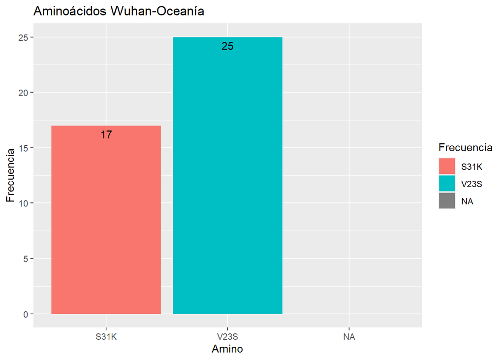

Las gráficas mostradas previamente demuestran la comparativa entre la variante original de Wuhan y 5 variantes diferentes identificadas en Oceanía, siendo el pangolin de las variantes B.1.1.136, mientras que para la cadena de Wuhan unicamente es una B, esto se utiliza para poder clasificar el tipo de variante que se está investigando, a continuación se pueden observar las gráficas comparativas entre una variante encontrada en Kansas PP301014 con las mismas 5 variantes encontradas en Oceanía. Esto con la finalidad de poder observar algún otro tipo de cambio entre las variantes de diferentes regiones.

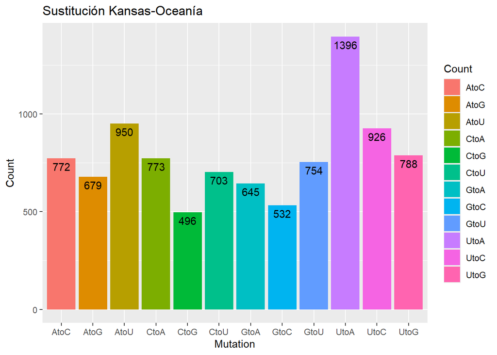

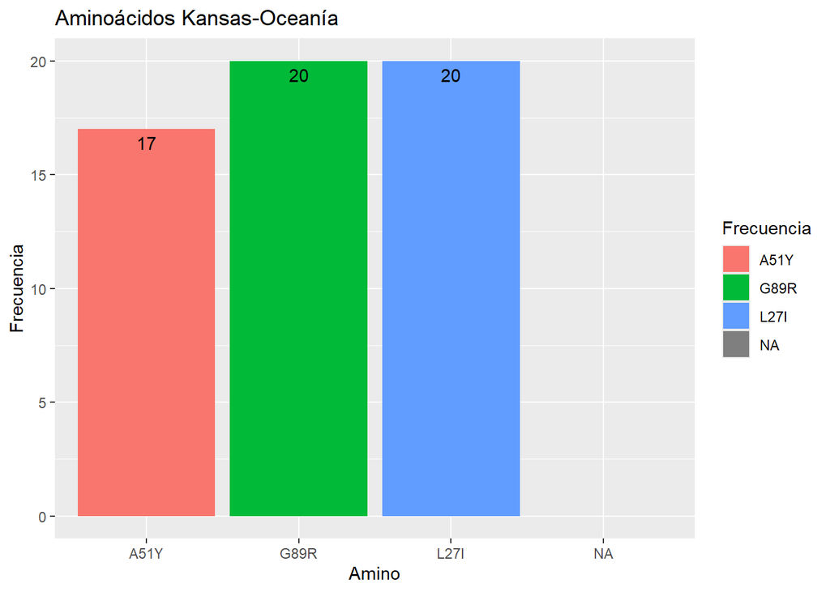

Las siguientes gráficas muestran la comparación que se realiza entre las cadenas de las variantes de Wuhan y Kansas para poder identificar con mayor facilidad las diferencias en los aminoácidos que existan en la variante de Oceanía que hacen que estas variantes no lleguen a otras partes del mundo, o en su defecto se originen únicamente en esa región.

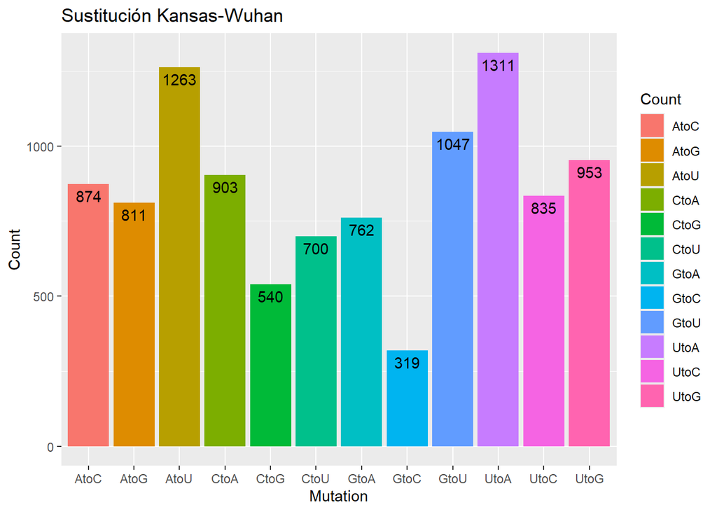

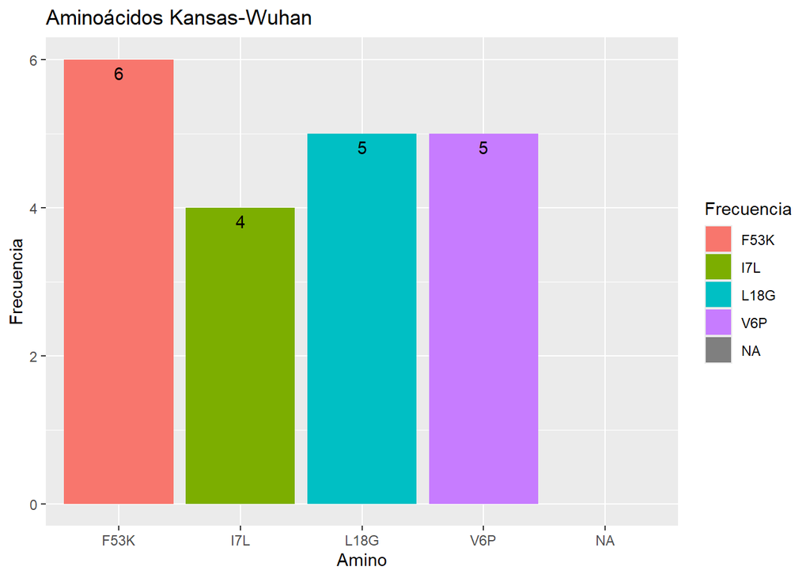

### Conclusiones

La lisina tiene como objetivo principal la producción de anticuerpos, lo que podría aplicarse en el virus para la inhibición de los anticuerpos del huésped, o para generar resistencia a los sistemas de defensa del mismo. El aminoácido K también es crucial para la conversión de ácidos en energía, lo que es fundamental para la multiplicación del virus.

Por otro lado, la Serina desempeña una función importante en la síntesis de otros aminoácidos y en la producción de energía. Dada su diversidad en estas regiones, esto podría ayudar en la propagación del virus. La Serina también juega un papel en la regulación de las proteínas y en la transcripción y traducción de las diversas cadenas de ARN y ADN del virus.